# The Base Plotting System in ggplot2

## Changing the Theme

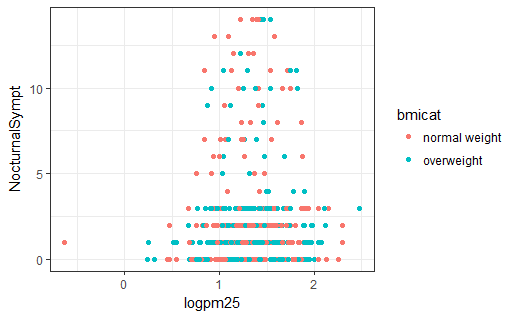

```r
g + geom_point(aes(color = bmicat)) + theme_bw(base_family = "Times")
```

## A Note about Axis Limits

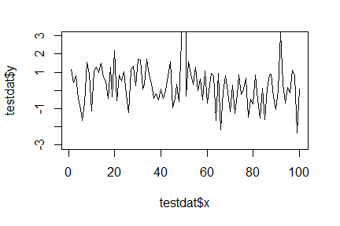

```r
testdat <- data.frame(x = 1:100, y = rnorm(100))
testdat[50,2] <- 100  ## Outlier!
plot(testdat$x, testdat$y, type = "l", ylim = c(-3,3))
```

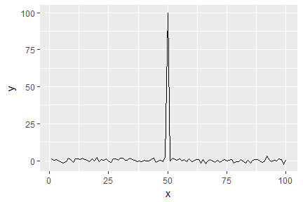

```r
g <- ggplot(testdat, aes(x = x, y = y))
g + geom_line()
```

## Axis Limits

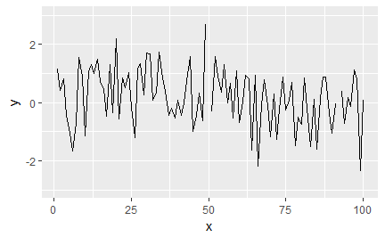

```r
g + geom_line() + ylim(-3, 3)
```

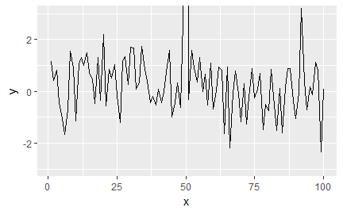

```r
g + geom_line() + coord_cartesian(ylim = c(-3, 3))
```

## More Complex Example

- How does the relationship between PM$_{2.5}$ and nocturnal symptoms vary by BMI and NO$_2$?
- Unlike our previous BMI variable, NO$_2$ is continuous
- We need to make NO$_2$ categorical so we can condition on it in the plotting
- Use the `cut()` function for this

## Making NO$_2$ Tertiles

```r
## Calculate the tertiles of the data
cutpoints <- quantile(maacs$logno2_new, seq(0, 1, length = 4), na.rm = TRUE)
## Cut the data at the tertiles and create a new factor variable
maacs$no2tert <- cut(maacs$logno2_new, cutpoints)
## See the levels of the newly created factor variable
levels(maacs$no2tert)
```

```
[1] "(-0.629,1.18]" "(1.18,1.44]"   "(1.44,2.48]"
```

## Final Plot

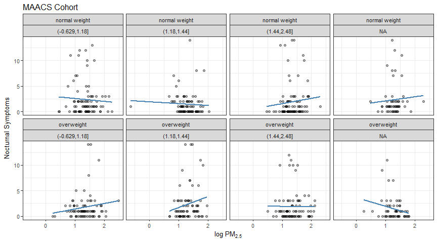

## Code for Final Plot

```r
## Setup ggplot with data frame
g <- ggplot(maacs, aes(logpm25, NocturnalSympt))

## Add layers
g + geom_point(alpha = 1/3) +
  facet_wrap(bmicat ~ no2tert, nrow = 2, ncol = 4) +
  geom_smooth(method="lm", se=FALSE, col="steelblue") +
  theme_bw(base_family = "Avenir", base_size = 10) +
  labs(x = expression("log " * PM[2.5])) +
  labs(y = "Nocturnal Symptoms") +
  labs(title = "MAACS Cohort")
```

## Summary

- ggplot2 is very powerful and flexible if you learn the ‘grammar’ and the various elements that can be tuned/modified
- Many more types of plots can be made; explore and mess around with the package (references mentioned in Part 1 are useful)